# CCHS PUMF Analysis

## Imports

```python
import duckdb
import pandas as pd
import numpy as np
import matplotlib.pyplot as plt
import statsmodels.api as sm
import statsmodels.formula.api as smf
from statsmodels.stats.outliers_influence import variance_inflation_factor
from sklearn.pipeline import make_pipeline
from sklearn.model_selection import KFold, cross_val_score
from sklearn.linear_model import LogisticRegression
from sklearn.ensemble import RandomForestClassifier
from sklearn.preprocessing import StandardScaler
```

## Wrangling with SQL

Let us first query the CCHS data to extract the relevant properties for the analysis. We will use the `duckdb` library.

```python
# set an in-memory connection
conn = duckdb.connect(database=":memory:")

# CREATE a table called cchs with all columns from the locally stored csv
conn.sql("""
CREATE TABLE cchs
AS SELECT * FROM read_csv_auto('data/pumf_cchs.csv')
""")

# SELECT the relevant columns for analysis, then filter the data
conn.sql("""
COPY (
    SELECT
        DHHGAGE,
        ECVG15,
        COLMODEY,
        DHH_SEX,
        GEN_01,
        GEN_05,
        GEN_10,
        GEN_20,
        LSM_01,
        CCC_135,
        CC1_140
    FROM cchs
    WHERE ECVG15 IN (1,2)
        AND DHHGAGE = 1
        AND COLMODEY IN (1,2)
        AND GEN_01 IN (1,2,3,4,5)
        AND GEN_05 IN (1,2,3,4,5)
        AND GEN_10 IN (1,2,3,4,5)
        AND GEN_20 IN (1,2,3,4)
        AND LSM_01 IN (0,1,2,3,4,5,6,7,8,9,10)
        AND CCC_135 IN (1,2)
        AND CC1_140 IN (1,2)
)
TO 'data/cchs-queried.csv'
(FORMAT CSV, HEADER)
""")
```

## Wrangling with `pandas`

We will now examine the data with Python.

```python
data = pd.read_csv("data/cchs-queried.csv")
```

Let us rename the columns to be more clear and intuitive:

```python
data.rename(columns={
    'ECVG15': 'vaping',
    'COLMODEY' : 'clct_mthd',
    'DHH_SEX' : 'sex',
    'GEN_01' : 'perc_gen_health',
    'GEN_05' : 'perc_ment_health',
    'GEN_10' : 'perc_stress',
    'GEN_20' : 'sens_blng',
    'LSM_01' : 'life_satis',
    'CCC_135' : 'mood_disdr',
    'CC1_140' : 'anx_disdr'},inplace=True)
```

We need to change the values in our DV from 1s and 2s to 0s and 1s.

```python
data['vaping'] = data['vaping'].replace({
    2: 0,
    1: 1
})
```

Let us update some values to make them clearer as well:

*Collection method*

```python
data['clct_mthd'] = data['clct_mthd'].replace({
    1: 'questionnaire',
    2: 'telephone'
})
```

*Sex*

```python
data['sex'] = data['sex'].replace({
    1: 'male',
    2: 'female'
})
```

*Mood disorder*

*where 1 == a mood disorder, and 0 == no mood disorder*

```python
data['mood_disdr'] = data['mood_disdr'].replace({
    1: 1,
    2: 0
})
```

*Anxiety disorder*

*where 1 == an anxiety disorder, and 0 == no anxiety disorder*

```python
data['anx_disdr'] = data['anx_disdr'].replace({
    1: 1,
    2: 0
})
```

Let us take a look at the cleaned data frame:

```python
display(data)
```

|  | DHHGAGE | vaping | clct_mthd | sex | perc_gen_health | perc_ment_health | perc_stress | sens_blng | life_satis | mood_disdr | anx_disdr |
| --- | --- | --- | --- | --- | --- | --- | --- | --- | --- | --- | --- |
| 0 | 1 | 0 | telephone | male | 1 | 3 | 3 | 2 | 8 | 0 | 1 |
| 1 | 1 | 0 | telephone | female | 2 | 3 | 2 | 2 | 8 | 0 | 0 |
| 2 | 1 | 1 | telephone | male | 2 | 2 | 3 | 1 | 9 | 0 | 0 |
| 3 | 1 | 0 | questionnaire | male | 3 | 5 | 2 | 2 | 6 | 1 | 0 |
| 4 | 1 | 0 | telephone | male | 1 | 2 | 4 | 3 | 10 | 0 | 1 |
| ... | ... | ... | ... | ... | ... | ... | ... | ... | ... | ... | ... |
| 442 | 1 | 1 | questionnaire | male | 1 | 1 | 3 | 2 | 8 | 0 | 0 |
| 443 | 1 | 0 | telephone | male | 3 | 3 | 2 | 3 | 7 | 0 | 0 |
| 444 | 1 | 0 | telephone | female | 2 | 2 | 2 | 2 | 8 | 0 | 0 |
| 445 | 1 | 1 | telephone | female | 2 | 3 | 4 | 2 | 7 | 0 | 0 |
| 446 | 1 | 1 | questionnaire | male | 3 | 4 | 5 | 1 | 3 | 0 | 0 |

447 rows × 11 columns

**NoteWhat do these values represent?**

`perc_gen_health`, `perc_ment_health`, and `sens_blng` are coded such that higher values = worse perceived health/sense of belonging.

`perc_stress` is coded so that higher values = more stress.

In contrast, for `life_satis`, higher scores = higher life satisfaction.

This project focuses on the factors that are associated with self-reports of recent e-cigarette use in a youth sample. We will explore whether certain variables change the predicted probability of e-cigarette use in the past month.

Since our dependent variable is binary, we will implement a logistic regression.

## Logistic regression with `statsmodels`

It is important to assess whether the predictors that we’ll include in our model are highly related to each other. The logistic model could end up having difficulty estimating the effect of certain predictors if they are closely related.

We’ll assess this assumption using the variance inflation factor of each predictor. Typically, a VIF of 1 means there is no multi-collinearity. 5-10 is cause for some concern, and > 10 means the estimates from those predictors are unstable.

### Check VIF:

```python
x = data[[
    'perc_gen_health',
    'perc_ment_health',
    'perc_stress',
    'sens_blng',
    'life_satis',
    'mood_disdr',
    'anx_disdr'
]]

corr_vars = ['life_satis', 'sens_blng', 'perc_gen_health', 'perc_ment_health', 'perc_stress', 'mood_disdr', 'anx_disdr']

cnst = sm.add_constant(x[corr_vars])

vif_data = pd.DataFrame()
vif_data['feature'] = corr_vars
vif_data['VIF'] = [variance_inflation_factor(cnst.values, i) for i in range(1, cnst.shape[1])]
print(vif_data.sort_values('VIF', ascending=False))
```

```
            feature       VIF
3  perc_ment_health  2.820901
0        life_satis  1.888087
2   perc_gen_health  1.820586
4       perc_stress  1.670690
5        mood_disdr  1.612098
6         anx_disdr  1.494472
1         sens_blng  1.246628
```

**NoteCorrecting an earlier mistake**

In v1.0, I forgot to add the `sm.add_constant()` line, rendering my VIF values highly inflated. Here, we see that the variables are only modestly related.

With this assumption tested, we can now move on to the main part of the analysis.

### Fit the model

```python
mod = smf.logit('vaping ~ perc_gen_health + perc_ment_health + perc_stress + sens_blng + life_satis + mood_disdr + anx_disdr', data=data).fit()
```

```
Optimization terminated successfully.
         Current function value: 0.663565
         Iterations 5
```

We can then generate a summary of the model:

```python
print(mod.summary())
```

```
                           Logit Regression Results
==============================================================================
Dep. Variable:                 vaping   No. Observations:                  447
Model:                          Logit   Df Residuals:                      439
Method:                           MLE   Df Model:                            7
Date:                Sat, 21 Nov 2026   Pseudo R-squ.:                 0.03429
Time:                        16:03:59   Log-Likelihood:                -296.61
converged:                       True   LL-Null:                       -307.15
Covariance Type:            nonrobust   LLR p-value:                  0.003677
====================================================================================
                       coef    std err          z      P>|z|      [0.025      0.975]
------------------------------------------------------------------------------------
Intercept            1.2831      0.874      1.469      0.142      -0.429       2.995
perc_gen_health      0.2126      0.138      1.540      0.124      -0.058       0.483
perc_ment_health    -0.0683      0.137     -0.498      0.619      -0.337       0.201
perc_stress         -0.0003      0.132     -0.002      0.998      -0.259       0.258
sens_blng           -0.4367      0.141     -3.108      0.002      -0.712      -0.161
life_satis          -0.1316      0.070     -1.892      0.059      -0.268       0.005
mood_disdr           0.4218      0.315      1.338      0.181      -0.196       1.040
anx_disdr            0.0951      0.266      0.357      0.721      -0.427       0.617
====================================================================================
```

When looking at the summary, we see that a weaker sense of community belonging is associated with a lower likelihood of recent youth e-cigarette use. Youth life satisfaction is also associated with vaping status, although this effect was marginally significant.

Let us explore the average marginal effects from the model to understand how much a single unit increase in a given predictor relates to the likelihood of e-cigarette use.

### Marginal effects

```python
margeff = mod.get_margeff()
print(margeff.summary())
```

```
        Logit Marginal Effects
=====================================
Dep. Variable:                 vaping
Method:                          dydx
At:                           overall
====================================================================================
                      dy/dx    std err          z      P>|z|      [0.025      0.975]
------------------------------------------------------------------------------------
perc_gen_health      0.0501      0.032      1.556      0.120      -0.013       0.113
perc_ment_health    -0.0161      0.032     -0.498      0.618      -0.079       0.047
perc_stress      -7.685e-05      0.031     -0.002      0.998      -0.061       0.061
sens_blng           -0.1029      0.032     -3.243      0.001      -0.165      -0.041
life_satis          -0.0310      0.016     -1.921      0.055      -0.063       0.001
mood_disdr           0.0994      0.074      1.349      0.177      -0.045       0.244
anx_disdr            0.0224      0.063      0.357      0.721      -0.101       0.145
====================================================================================
```

In this table, we observe that, for every one unit increase in a youth’s sense of belonging (as it gets *worse*), there is an associated 10.3 percentage point decrease in their likelihood to report e-cigarette use in the past month. Further, we see a marginal effect of life satisfaction. E-cigarette use is associated with a 3.1 percentage point decrease for every single-unit increase.

We will visualize these marginal effects next.

### Convert to data frame for plotting

```python
margeff_df = pd.DataFrame({
    'variable': mod.model.exog_names[1:],
    'dydx': margeff.margeff * 100,
    'std_err': margeff.margeff_se,
    'p_value': margeff.pvalues,
    'ci_low': margeff.conf_int()[:, 0] * 100,
    'ci_high': margeff.conf_int()[:, 1] * 100
})
```

Rename variables for plot readability

```python
margeff_df['variable'] = margeff_df['variable'].replace({
    'perc_gen_health': 'Perceived General Health',
    'perc_ment_health': 'Perceived Mental Health',
    'perc_stress': 'Perceived Life Stress',
    'sens_blng': 'Sense of Community Belonging',
    'life_satis': 'General Life Satisfaction',
    'mood_disdr': 'Mood Disorder',
    'anx_disdr': 'Anxiety Disorder',
})
```

### Visualize the marginal effects

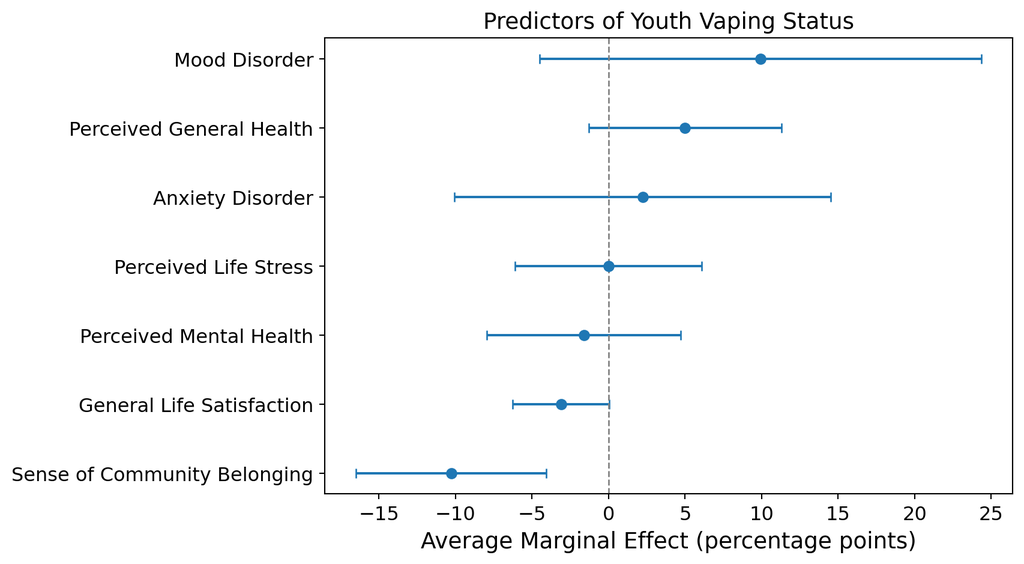

```python
margeff_df = margeff_df.sort_values('dydx')

fig, ax = plt.subplots(figsize=(9,5))

ax.errorbar(
    margeff_df['dydx'], margeff_df['variable'],
    xerr=[margeff_df['dydx'] - margeff_df['ci_low'],
          margeff_df['ci_high'] - margeff_df['dydx']],
    fmt='o', capsize=3
)
ax.axvline(0, linestyle='--', color='gray', linewidth=1)
ax.set_xlabel('Average Marginal Effect (percentage points)')
ax.set_title('Predictors of Youth Vaping Status')
plt.tight_layout()
plt.savefig("plot.jpg")
plt.show()
```

*Note:* Error bars represent 95% confidence intervals

### Interim conclusion

The logistic regression tells us that some predictors are associated with a decrease in the likelihood of youth e-cigarette use in the last month. We used a linear model here, but what happens if we implement a more flexible approach? In this next step, we’ll use a random forest machine learning algorithm to assess whether the psychological variables we’ve explored can classify current e-cigarette users from past users. Does this flexible model find a signal where the linear model does not?

## Classification: Random forest versus logistic regression

**NoteCorrecting an earlier mistake**

In v1.0, I used a simple train/test split method to train the model. To give more stable estimates for this sample size, each model is cross-validated at ten folds.

First, we will state what our predictor and outcome variables are.

```python
y = data['vaping']

models = {
"Logistic regression": make_pipeline(
    StandardScaler(),
    LogisticRegression(max_iter=1000)),
"Random forest": RandomForestClassifier(n_estimators=500, min_samples_leaf=10, random_state=50)}
```

**NoteNote on the logistic regression**

This logistic model uses the same predictors as our earlier model. Note, though, that the current model is fit with `sklearn`, rather than `statsmodels`. The difference is that the earlier model was used to describe associations while the latter is used for classification.

Let’s next look into class balance – what proportion of the sample reports vaping in the past month?

If these classes are unbalanced, we might want to proceed with a stratified K-fold approach, rather than a standard K-fold cross-validation.

```python
# First, let us get the counts for the number of 1s and 0s

col_count = y.value_counts()

# Then we can get the proportions
col_prop = y.value_counts(normalize=True)

# And we can combine these into a single dataframe

col_concat = pd.concat([col_count,col_prop], axis=1, keys=['count','proportion'])

print(col_concat)
```

```
        count  proportion
vaping
0         248     0.55481
1         199     0.44519
```

We find that the classes are quite balanced. We’ll go forward with the typical K-fold method.

### Cross-validate each model:

```python
k_fold = KFold(n_splits=10, shuffle=True, random_state=51)

with np.errstate(invalid='ignore', divide='ignore', over='ignore'):
    auc = {
        name: cross_val_score(model, x, y, cv=k_fold, scoring='roc_auc')
            for name, model in models.items()
    }

auc_df = pd.DataFrame(auc)
print(auc_df.round(3))
print(auc_df.agg(['mean', 'std']).round(3))
```

```
   Logistic regression  Random forest
0                0.585          0.517
1                0.522          0.497
2                0.625          0.589
3                0.666          0.735
4                0.484          0.675
5                0.534          0.561
6                0.623          0.744
7                0.634          0.689
8                0.438          0.361
9                0.541          0.626
      Logistic regression  Random forest
mean                0.565           0.60
std                 0.073           0.12
```

**Note**

Note that I’ve silenced an erroneous `numpy` warning that appears on Apple Silicon Macs. I’ve verified that the data do not include missing or infinite values, or `NaNs`:

```python
print(x.isna().sum().sum(), np.isfinite(x.to_numpy(dtype=float)).all())
```

```
0 True
```

See [numpy#28687](https://github.com/numpy/numpy/issues/28687) and [scikit-learn#31395](https://github.com/scikit-learn/scikit-learn/issues/31395) for more info.

### Results

We observe that the mean AUC scores between the logistic regression and random forest algorithm are similar. For both models, the average ability to discriminate between current and past e-cigarette users is modestly above chance (random guessing).

Our earlier question, regarding whether a different pattern might emerge when we adopt a non-linear approach has been answered. It appears that the psychological variables we are interested in do not remove much uncertainty from these models when they make classifications.

### Conclusions

Overall, we’ve asked two distinct questions in this analysis. First, how are psychological predictors (e.g., perceived mental health) associated with changes in the likelihood of e-cigarette use in the past month, among Canadian youth? We saw that a weaker youth sense of belonging was associated with decreases in e-cigarette use: as belonging gets weaker, the likelihood to vape decreases. Further, we observed a marginal association: higher life satisfaction scores were related to a slightly lower likelihood of recent e-cigarette use.

Our second question had to do with classifying members of our youth sample as current or past e-cigarette users. We found that both a logistic regression (mean AUC = 0.57) and a random forest machine learning algorithm (mean AUC = 0.60) did modestly better than chance when discriminating between these two classes. The flexible model found little additional signal. Instead, these variables likely hold little predictive value when it comes to determining recent e-cigarette use.

### Limitations

Importantly, these data are cross-sectional. Therefore, the significant predictors in our first logistic regression are merely *associated with* decreases in the likelihood of recent e-cigarette use. We cannot make causal inferences about these data. Additionally, I did not control for age or sex here, nor did I use survey weights. This latter point means that these results describe the current sample rather than all Canadian youth.

For a write-up of these data, see `brief.pdf`